# Reporte Ejecutivo - Base Analítica de Cobranzas

Alejandra Julio Ramírez

# 1 1. Objetivo del reporte

Este reporte muestra y explica los resultados generados por la **base analítica de cobranzas**. Su propósito es traducir los archivos técnicos del proceso en información útil para el área financiera y comercial.

En particular, se revisan los principales outputs generados por el script:

- `indicadores_cartera.csv`
- `resumen_cobranza.csv`
- `base_cobranza.csv`
- `top10_facturas_vencidas.csv`
- `top10_mayor_riesgo.csv`
- `top10_mas_facturas.csv`
- `top10_unificado.csv`
- `clientes_criticos_3mas_vencidas.csv`
- `clientes_prioritarios.csv`

# 2 2. Carga de resultados

En esta sección se cargan todos los archivos generados por el proceso de cobranzas. Si alguno no existe, significa que el script no se ejecutó completamente o que la ruta de salida no es correcta.

# 3 3. Indicadores generales de cartera

Indicadores generales de la cartera

| FechaEjecucion | Clientes | Facturas | FacturasVencidas | MontoVencido | DiasMoraPromedioCartera |
| --- | --- | --- | --- | --- | --- |
| 2026-03-20 | 232 | 3.998 | 214 | $58.916.353 | 53 |

## 3.1 ¿Qué significa esta tabla?

Esta tabla resume el estado global de la cartera al momento de la ejecución:

- **Clientes**: número de clientes analizados.
- **Facturas**: total de documentos incluidos.
- **FacturasVencidas**: cantidad de facturas que ya están vencidas.
- **MontoVencido**: exposición monetaria actualmente vencida.
- **DiasMoraPromedioCartera**: atraso promedio entre las facturas vencidas.

**Interpretación para negocio:**  
Esta es la vista más ejecutiva del proceso. Permite responder rápidamente cuánto riesgo operativo hay hoy en la cartera y cuánta presión existe sobre cobranza.

# 4 4. Base consolidada de cobranza

## 4.1 ¿Qué muestra este archivo?

`base_cobranza.csv` corresponde a la unión entre facturas y clientes. Aquí se observan variables documentales y comerciales, junto con campos calculados como:

- **Estado** de la factura
- **Dias_Mora**
- datos del cliente asociados al RUT

**Interpretación:**  
Esta base permite bajar al detalle de cada documento. Es útil para revisar casos puntuales, validar resultados y realizar seguimiento operativo.

## 4.2 Distribución del estado de facturas

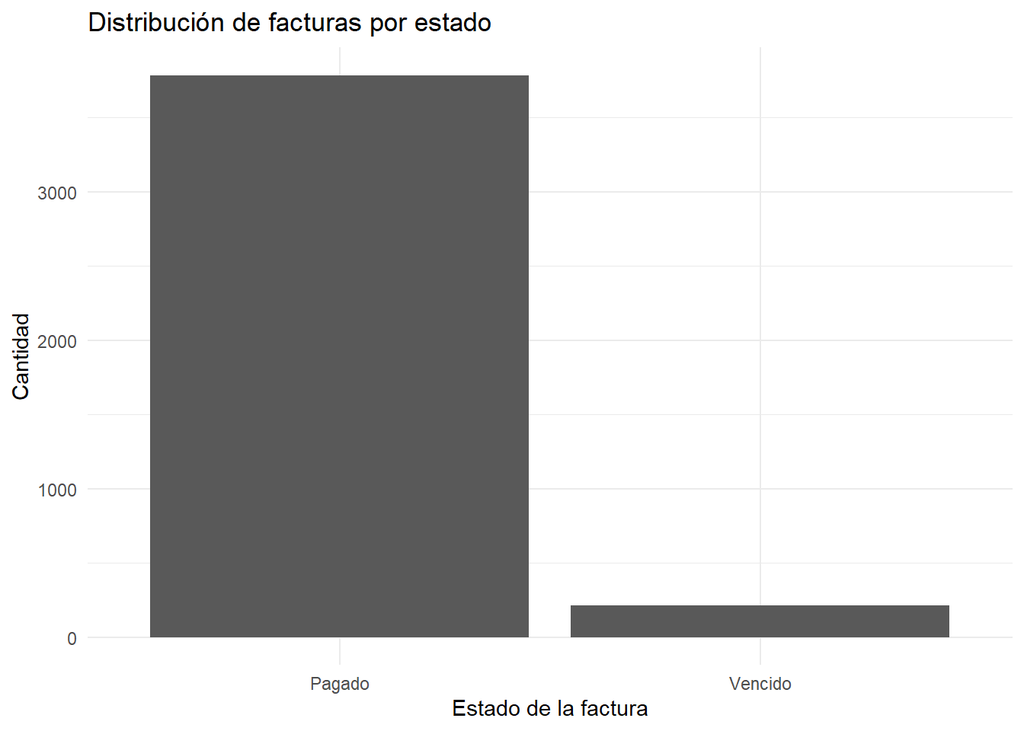

# 5 5. Resumen por cliente y scoring de riesgo

Primeras 10 filas del resumen de cobranza por cliente

| Rut | Cliente | NumFacturas | NumVencidas | MontoVencido | DiasMoraProm | DiasMoraMax | kpi_monto | kpi_mora | kpi_venc | score_riesgo | Riesgo |
| --- | --- | --- | --- | --- | --- | --- | --- | --- | --- | --- | --- |
| 1 | A | 31 | 0 | 0 | 0.00000 | 0 | 0.0000000 | 0.0000000 | 0.0000000 | 0.0000000 | Bajo |
| 2 | B | 30 | 1 | 111121 | 47.00000 | 47 | 0.0329040 | 0.4311927 | 0.3333333 | 0.2124765 | Medio |
| 3 | C | 31 | 3 | 141590 | 78.33333 | 109 | 0.0419262 | 0.7186544 | 1.0000000 | 0.4365594 | Alto |
| 4 | D | 21 | 1 | 233448 | 47.00000 | 47 | 0.0691263 | 0.4311927 | 0.3333333 | 0.2305876 | Medio |
| 6 | F | 25 | 0 | 0 | 0.00000 | 0 | 0.0000000 | 0.0000000 | 0.0000000 | 0.0000000 | Bajo |
| 7 | G | 30 | 1 | 942870 | 47.00000 | 47 | 0.2791932 | 0.4311927 | 0.3333333 | 0.3356211 | Alto |
| 8 | H | 31 | 1 | 82749 | 47.00000 | 47 | 0.0245028 | 0.4311927 | 0.3333333 | 0.2082759 | Bajo |
| 9 | I | 30 | 1 | 232644 | 47.00000 | 47 | 0.0688882 | 0.4311927 | 0.3333333 | 0.2304686 | Medio |
| 10 | J | 18 | 0 | 0 | 0.00000 | 0 | 0.0000000 | 0.0000000 | 0.0000000 | 0.0000000 | Bajo |
| 11 | K | 30 | 1 | 246830 | 47.00000 | 47 | 0.0730888 | 0.4311927 | 0.3333333 | 0.2325689 | Alto |

## 5.1 ¿Qué muestra esta tabla?

`resumen_cobranza.csv` resume la situación de cada cliente con variables clave:

- **NumFacturas**
- **NumVencidas**
- **MontoVencido**
- **DiasMoraProm**
- **DiasMoraMax**
- **score_riesgo**
- **Riesgo** (Bajo, Medio, Alto)

**Interpretación:**  
Este archivo traduce el detalle documental a una mirada por cliente. Es la base para priorizar gestión y segmentar cartera.

## 5.2 Distribución del nivel de riesgo

Cantidad de clientes por nivel de riesgo

| Riesgo | n |
| --- | --- |
| Alto | 79 |
| Bajo | 78 |
| Medio | 75 |

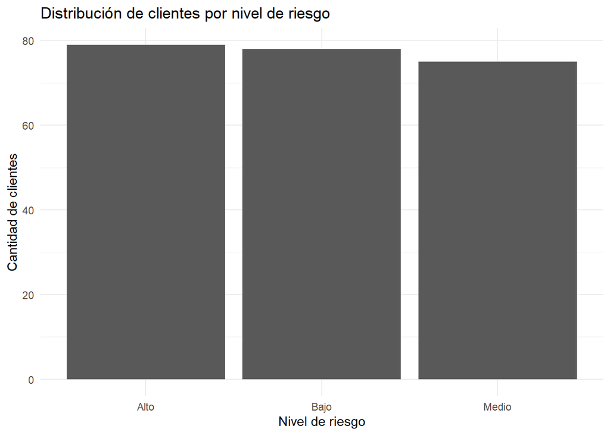

Este gráfico muestra cómo se distribuyen los clientes entre **riesgo bajo, medio y alto**.  
Si hay una alta concentración en riesgo alto, el área financiera debería revisar exposición y el área comercial ajustar seguimiento.

# 6 6. Top 10 clientes con más facturas vencidas

Top 10 clientes con mayor cantidad de facturas vencidas

| Rut | Cliente | NumFacturas | NumVencidas | MontoVencido | DiasMoraProm | DiasMoraMax |
| --- | --- | --- | --- | --- | --- | --- |
| 221 | HM | 3 | 3 | 631484 | 78.33333 | 109 |
| 168 | FL | 10 | 3 | 602672 | 78.33333 | 109 |
| 220 | HL | 3 | 3 | 311494 | 78.33333 | 109 |
| 41 | AO | 30 | 3 | 288842 | 78.33333 | 109 |
| 102 | CX | 19 | 3 | 198281 | 78.33333 | 109 |
| 3 | C | 31 | 3 | 141590 | 78.33333 | 109 |
| 19 | S | 31 | 2 | 2747878 | 63.00000 | 79 |
| 185 | GC | 8 | 2 | 1532682 | 63.00000 | 79 |
| 153 | EW | 12 | 2 | 1388582 | 63.00000 | 79 |
| 217 | HI | 4 | 2 | 1010017 | 47.00000 | 47 |

## 6.1 ¿Cómo interpretar esta tabla?

Aquí se identifican los clientes con mayor volumen de documentos vencidos.

**Uso práctico:** - priorizar gestión de cobranza, - identificar clientes con recurrencia de atraso, - detectar cuentas que consumen mucho esfuerzo operativo.

# 7 7. Top 10 clientes con mayor riesgo

Top 10 clientes con mayor riesgo

| Rut | Cliente | Riesgo | MontoVencido | NumVencidas | DiasMoraProm |
| --- | --- | --- | --- | --- | --- |
| 162 | FF | Alto | 3377124 | 1 | 47 |
| 19 | S | Alto | 2747878 | 2 | 63 |
| 196 | GN | Alto | 1803228 | 1 | 47 |
| 80 | CB | Alto | 1796704 | 1 | 47 |
| 182 | FZ | Alto | 1728659 | 1 | 37 |
| 15 | O | Alto | 1549448 | 1 | 47 |
| 185 | GC | Alto | 1532682 | 2 | 63 |
| 153 | EW | Alto | 1388582 | 2 | 63 |
| 203 | GU | Alto | 1215708 | 1 | 47 |
| 217 | HI | Alto | 1010017 | 2 | 47 |

## 7.1 ¿Cómo interpretar esta tabla?

Esta tabla combina monto vencido, número de facturas vencidas y mora promedio, pero enfocada en los clientes clasificados con mayor severidad.

**Uso práctico:** - identificar clientes que deberían revisarse primero, - evaluar contacto preventivo, - reforzar control de cartera con foco en exposición.

# 8 8. Top 10 clientes con más facturas

Top 10 clientes con mayor número de facturas

| Rut | Cliente | NumFacturas | NumVencidas | MontoVencido | DiasMoraProm |
| --- | --- | --- | --- | --- | --- |
| 22 | V | 42 | 0 | 0 | 0.00000 |
| 28 | AB | 35 | 0 | 0 | 0.00000 |
| 17 | Q | 33 | 1 | 472854 | 47.00000 |
| 14 | N | 32 | 0 | 0 | 0.00000 |
| 19 | S | 31 | 2 | 2747878 | 63.00000 |
| 31 | AE | 31 | 1 | 980604 | 47.00000 |
| 45 | AS | 31 | 1 | 346602 | 47.00000 |
| 3 | C | 31 | 3 | 141590 | 78.33333 |
| 18 | R | 31 | 1 | 92680 | 47.00000 |
| 8 | H | 31 | 1 | 82749 | 47.00000 |

## 8.1 ¿Qué aporta esta tabla?

No necesariamente son los más riesgosos, pero sí los que tienen mayor volumen documental.

**Interpretación:**  
Sirve para distinguir clientes con alta actividad del negocio. Algunos pueden tener muchas facturas sin ser problemáticos, pero merecen monitoreo por su peso operativo.

# 9 9. Ranking unificado de clientes relevantes

Top 10 unificado de clientes relevantes

| Rut | Cliente | Riesgo | MontoVencido | NumVencidas | NumFacturas | DiasMoraProm | DiasMoraMax |
| --- | --- | --- | --- | --- | --- | --- | --- |
| 162 | FF | Alto | 3377124 | 1 | 11 | 47 | 47 |
| 19 | S | Alto | 2747878 | 2 | 31 | 63 | 79 |
| 196 | GN | Alto | 1803228 | 1 | 6 | 47 | 47 |
| 80 | CB | Alto | 1796704 | 1 | 24 | 47 | 47 |
| 182 | FZ | Alto | 1728659 | 1 | 8 | 37 | 37 |
| 15 | O | Alto | 1549448 | 1 | 30 | 47 | 47 |
| 185 | GC | Alto | 1532682 | 2 | 8 | 63 | 79 |
| 153 | EW | Alto | 1388582 | 2 | 12 | 63 | 79 |
| 203 | GU | Alto | 1215708 | 1 | 6 | 47 | 47 |
| 217 | HI | Alto | 1010017 | 2 | 4 | 47 | 47 |

## 9.1 ¿Qué muestra?

Este ranking combina varios criterios a la vez:

- nivel de riesgo,
- monto vencido,
- número de facturas vencidas,
- total de facturas.

**Interpretación:**  
Es una tabla útil para gestión ejecutiva porque resume, en un solo ranking, los clientes que concentran mayor atención desde varias dimensiones.

## 9.2 Visualización del monto vencido de clientes más expuestos

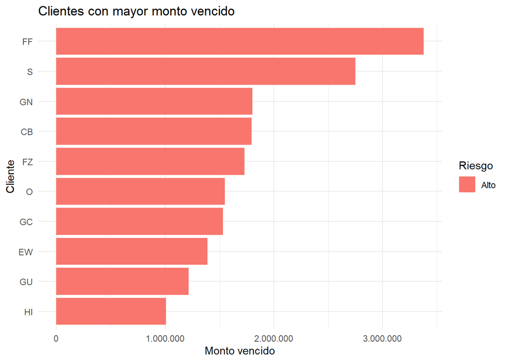

Este gráfico permite ver, de forma visual, qué clientes concentran más deuda vencida y bajo qué nivel de riesgo se encuentran.

# 10 10. Clientes críticos

Clientes críticos con 3 o más facturas vencidas

| Rut | Cliente | Riesgo | MontoVencido | NumVencidas | NumFacturas | DiasMoraProm | DiasMoraMax |
| --- | --- | --- | --- | --- | --- | --- | --- |
| 221 | HM | Alto | 631484 | 3 | 3 | 78.33333 | 109 |
| 168 | FL | Alto | 602672 | 3 | 10 | 78.33333 | 109 |
| 220 | HL | Alto | 311494 | 3 | 3 | 78.33333 | 109 |
| 41 | AO | Alto | 288842 | 3 | 30 | 78.33333 | 109 |
| 102 | CX | Alto | 198281 | 3 | 19 | 78.33333 | 109 |
| 3 | C | Alto | 141590 | 3 | 31 | 78.33333 | 109 |

## 10.1 ¿Qué significa?

Aquí se listan clientes que tienen **al menos 3 facturas vencidas**, por lo que representan un foco claro de atención.

**Interpretación para negocio:** - posible deterioro de pago, - mayor urgencia de contacto, - revisión prioritaria por parte de cobranza y finanzas.

# 11 11. Clientes prioritarios

Clientes prioritarios para gestión

| Rut | Cliente | Riesgo | MontoVencido | NumVencidas | NumFacturas | DiasMoraProm | DiasMoraMax | Prioridad |
| --- | --- | --- | --- | --- | --- | --- | --- | --- |
| 162 | FF | Alto | 3377124 | 1 | 11 | 47.00000 | 47 | 1 |
| 19 | S | Alto | 2747878 | 2 | 31 | 63.00000 | 79 | 2 |
| 196 | GN | Alto | 1803228 | 1 | 6 | 47.00000 | 47 | 3 |
| 80 | CB | Alto | 1796704 | 1 | 24 | 47.00000 | 47 | 4 |
| 182 | FZ | Alto | 1728659 | 1 | 8 | 37.00000 | 37 | 5 |
| 15 | O | Alto | 1549448 | 1 | 30 | 47.00000 | 47 | 6 |
| 185 | GC | Alto | 1532682 | 2 | 8 | 63.00000 | 79 | 7 |
| 153 | EW | Alto | 1388582 | 2 | 12 | 63.00000 | 79 | 8 |
| 203 | GU | Alto | 1215708 | 1 | 6 | 47.00000 | 47 | 9 |
| 217 | HI | Alto | 1010017 | 2 | 4 | 47.00000 | 47 | 10 |
| 221 | HM | Alto | 631484 | 3 | 3 | 78.33333 | 109 | 11 |
| 168 | FL | Alto | 602672 | 3 | 10 | 78.33333 | 109 | 12 |
| 220 | HL | Alto | 311494 | 3 | 3 | 78.33333 | 109 | 13 |
| 41 | AO | Alto | 288842 | 3 | 30 | 78.33333 | 109 | 14 |
| 102 | CX | Alto | 198281 | 3 | 19 | 78.33333 | 109 | 15 |
| 3 | C | Alto | 141590 | 3 | 31 | 78.33333 | 109 | 16 |

## 11.1 ¿Por qué esta tabla es clave?

`clientes_prioritarios.csv` reúne a los clientes más importantes de gestionar, considerando la combinación de criticidad y riesgo.

**Uso práctico:** - definir agenda de cobranza, - ordenar seguimiento comercial, - establecer foco diario o semanal del equipo.

# 12 12. Recomendaciones para toma de decisiones

## 12.1 12.1 Área de cobranzas

- usar `clientes_prioritarios.csv` como lista de gestión,
- revisar `clientes_criticos_3mas_vencidas.csv` para contacto urgente,
- apoyarse en `top10_facturas_vencidas.csv` para distribuir esfuerzos.

## 12.2 12.2 Área financiera

- monitorear `indicadores_cartera.csv` para seguir exposición vencida,
- revisar clientes de `top10_mayor_riesgo.csv` y `top10_unificado.csv`,
- complementar análisis con monto vencido y mora máxima.

## 12.3 12.3 Área comercial

- identificar clientes con señales tempranas de deterioro,
- coordinar con cobranza acciones preventivas,
- usar la clasificación de riesgo como apoyo a decisiones sobre continuidad, condiciones o seguimiento.

# 13 13. Conclusión

La base analítica de cobranzas transforma datos operacionales en un conjunto de salidas accionables para negocio.

En particular:

- `indicadores_cartera.csv` resume la situación general de la cartera,
- `base_cobranza.csv` permite revisar el detalle documental,
- `resumen_cobranza.csv` consolida KPIs por cliente,
- los rankings top ayudan a priorizar exposición y mora,
- `clientes_criticos_3mas_vencidas.csv` y `clientes_prioritarios.csv` orientan la gestión concreta.

De esta forma, el proceso no solo genera archivos, sino una herramienta útil para mejorar foco, trazabilidad y toma de decisiones.